# Designing Experiments and Instrumental Variables

László Kovács

2026-07-13

## 1. Causality, Confounding and Randomization

There are several different purposes for which we may wish to use the methods of statistical inference.

1. For prediction. For example we build a model of patients’ probability of heart disease based on lifestyle factors such as diet and exercise, estimate the model from a representative group of subjects whose heart disease status is known, and use it to predict the status of new subjects.
2. To establish association between variables. For example we suspect that being educated in a single sex school may be negatively associated with length of marriage, and use statistical modelling to assess whether this putative association is real, or could just be due to chance variability in the data.
3. To establish causation. Often, especially in science, we want to know whether something is an actual cause of something else. Famous examples are: does smoking cause cancer? and does the MMR vaccine cause autism?

The methods we have covered so far are quite sufficient for addressing 1 and 2, but the causal inference required in 3 is more difficult, and the sort of methods covered so far are not sufficient to establish causality on their own.

To understand the issues, it is important to really have grasped the difference between correlation (association) and causality. An oft quoted example is the correlation between the population of storks and the birth rate, in Europe. The correlation is real, but there is obviously no causation. Rather, industrialization raised health care, living and educational standards in Europe leading to reduced birth rates, but that same industrialization led to a reduction in suitable habitat for storks. That is, the association is caused by other factors which may be causative to both variables of interest.

Confusing correlation with causation is a famously good way of selling newspapers. A study from the university of Bath was reported as revealing that men who preferred women with a smaller than usual hip to waist ratio were more likely to have autistic children. The association was real, but it was the interpretation in terms of the preference being somehow causative that made the story interesting. In fact, the likely explanation of the association is that higher than average testosterone in the womb seems to be a causative factor in autism, and women with higher than average testosterone tend to have smaller than usual hip to waist ratio. For obvious reasons they also tend to have children with men who find them attractive. This explanation makes for a duller press release, of course. Again the key is a hidden variable related to the variables of direct interest.

### 1.1 Confounding: Simulated Examples

To appreciate the effect of correlated predictors on interpretation and attempts at causal inference, it is worth looking at some simulations, where we are in complete control of the correlation structure between variables. The following code simulates two correlated predictor variables, $x$ and $h$:

```r
require(mgcv) # supplies rmvn
V <- matrix(c(1,0.95,0.95,1),2,2) # correl matrix
n <- 1000 # number of data

set.seed(7)
X <- rmvn(n,rep(0,2),V)
x <- X[,1];h <- X[,2]
```

Now consider the case when $y_i = 1 \times x_i + \epsilon_i$ , but we fit the model $y_i = \beta_0 + \beta_1x_i + \beta_2h_i + \epsilon_i$

```r
y <- 1*x + rnorm(n)
summary(lm(y ~ x + h))
```

```
##
## Call:
## lm(formula = y ~ x + h)
##
## Residuals:
##     Min      1Q  Median      3Q     Max
## -3.5815 -0.6478 -0.0026  0.6114  2.9705
##
## Coefficients:
##              Estimate Std. Error t value Pr(>|t|)
## (Intercept) -0.003268   0.031170  -0.105   0.9165
## x            0.812568   0.098924   8.214 6.59e-16 ***
## h            0.209603   0.099475   2.107   0.0354 *
## ---
## Signif. codes:  0 '***' 0.001 '**' 0.01 '*' 0.05 '.' 0.1 ' ' 1
##
## Residual standard error: 0.9855 on 997 degrees of freedom
## Multiple R-squared:  0.5147, Adjusted R-squared:  0.5137
## F-statistic: 528.7 on 2 and 997 DF,  p-value: < 2.2e-16
```

```r
summary(lm(y ~ x ))
```

```
##
## Call:
## lm(formula = y ~ x)
##
## Residuals:
##     Min      1Q  Median      3Q     Max
## -3.5078 -0.6561  0.0074  0.6067  2.9379
##
## Coefficients:
##              Estimate Std. Error t value Pr(>|t|)
## (Intercept) -0.002117   0.031219  -0.068    0.946
## x            1.010417   0.031191  32.395   <2e-16 ***
## ---
## Signif. codes:  0 '***' 0.001 '**' 0.01 '*' 0.05 '.' 0.1 ' ' 1
##
## Residual standard error: 0.9872 on 998 degrees of freedom
## Multiple R-squared:  0.5126, Adjusted R-squared:  0.5121
## F-statistic:  1049 on 1 and 998 DF,  p-value: < 2.2e-16
```

Because of the high correlation between $x$ and $h$ it is difficult to distinguish their effects, with the result that when both are included in the model the ‘explanation’ of the response tends to get shared out between them, leading to rather variable estimates of the real effect of $x$. In contrast when the spurious $h$ term is omitted from the model, the estimate of $\beta_1$ is much more accurate. Actually, for most replicates of the data simulation, $\beta_2$ would not have appeared to be significantly different from zero, so we would have been likely to drop the term, and arrive at the correct model using just the inferential tools already developed.

However, it is worth also looking at what would have happened if we had only observe $h$ but not $x$:

```r
summary(lm(y ~ h))
```

```
##
## Call:
## lm(formula = y ~ h)
##
## Residuals:
##     Min      1Q  Median      3Q     Max
## -3.8649 -0.6855  0.0280  0.6547  3.0157
##
## Coefficients:
##              Estimate Std. Error t value Pr(>|t|)
## (Intercept) -0.007193   0.032187  -0.223    0.823
## h            0.985161   0.032336  30.466   <2e-16 ***
## ---
## Signif. codes:  0 '***' 0.001 '**' 0.01 '*' 0.05 '.' 0.1 ' ' 1
##
## Residual standard error: 1.018 on 998 degrees of freedom
## Multiple R-squared:  0.4819, Adjusted R-squared:  0.4814
## F-statistic: 928.2 on 1 and 998 DF,  p-value: < 2.2e-16
```

The high correlation between $h$ and $x$ means that we find a strongly significant association between $h$ and $y$, despite the fact that $h$ played no part at all in the simulation of $y$! In this case $x$ is an example of a hidden confounding variable: it is correlated with both our predictor, $h$, and our response $y$, and therefore messes up our inference about the true causal influence of $h$ on $y$ (which is zero in this case).

Here is a second example of confounding. Now both $h$ and $x$ have a causal effect on $y$, and if we only observe $x$, we will overestimate its true effect (overestimate, because the correlation is positive).

```r
y <- x + h + rnorm(n)
summary(lm(y ~ x ))
```

```
##
## Call:
## lm(formula = y ~ x)
##
## Residuals:
##     Min      1Q  Median      3Q     Max
## -2.8885 -0.6959  0.0082  0.7092  3.1723
##
## Coefficients:
##             Estimate Std. Error t value Pr(>|t|)
## (Intercept)  0.01714    0.03249   0.528    0.598
## x            1.92020    0.03246  59.155   <2e-16 ***
## ---
## Signif. codes:  0 '***' 0.001 '**' 0.01 '*' 0.05 '.' 0.1 ' ' 1
##
## Residual standard error: 1.027 on 998 degrees of freedom
## Multiple R-squared:  0.7781, Adjusted R-squared:  0.7779
## F-statistic:  3499 on 1 and 998 DF,  p-value: < 2.2e-16
```

i.e. when h is hidden from us, our estimate of $\beta_1$ is almost twice as large as it should be in this case.

Note that this tendency of the model fitting to try and compensate for missing confounding variables, is a profound difficulty for causal inference, but a blessing for prediction. The fact that the model has adjusted for the missing confounders in this way actually improves prediction.

### 1.2 Controlled Experiments and Randomization

The gold standard for establishing causality is to analyse data from a properly designed experiment, in which we use the process of randomization to break any possible association between unmeasured confounders and the predictor whose effect we want to measure. The idea is basically to turn the systematic variation in the response caused by confounders into something that we can model as independent random variability between experimental units.

An example is the most useful way to convey the idea. Suppose that we want to examine the relationship between exercise and fat mass in people aged 40 to 50. There are a huge number of factors contributing to people’s fat mass, and if we simply look at a sample of people who already exercise by different amounts it will be very difficult to isolate the effect of exercise separate from all the other confounders (diet, working hours, profession, whether they have children, drinking habits, smoking, wealth etc.). Suppose instead that we set up a study in which participants enroll and are then assigned to one of several ‘treatments’, consisting of exercise programs of differing intensity (or a control of none). Now if we assign subjects to the different treatments randomly then there can be no possible association between all the other variables contributing to fat mass, and the one that we are interested in: amount of exercise. Indeed all the variability in fat mass attributable to the confounders can now be treated as random variability within each treatment. Any effect of exercise that we then find is causal: the thing we controlled having an effect on the variable we are interested in. Of course this approach does not stop us from including measured explanatory variables (in other words: covariates) in the analysis model, in order to reduce the amount of variability being modeled as random, and thereby increase precision, but it does mean that we no longer have to worry about the effect of hidden confounders.

## 2. Instrumental variables

So properly designed controlled experiments with random allocation of experimental units to treatments are the best way of establishing causal effects. However there are many cases in which experimental manipulation is impractical, unethical and/or illegal. For example, if we are interested in establishing the causative effect of alcohol consumption on heart disease, it is simply unethical to conduct a study in which we randomly allocate subjects to a heavy drinking treatment (the same goes for any treatment where we have prior cause to suspect it may be harmful). Economics is another field beset with such problems: for example it is impractical to conduct a controlled experiment to establish the causative factors controlling a company’s share price, and anything that came close would likely count as illegal market manipulation. This sort of problem is so ubiquitous in economics that it is from the field of *econometrics* that much of the work on causal inference from observational data comes.

In this section we will look at one method: **instrumental variables (IVs)**. The approach can be applied more widely than just to linear regession models, but the ideas are easiest to grasp in the linear model context. Let’s again use the setup in which $x$ is the observed true expanatory variable of $y$, and $h$ is the hidden confounder that is not observed and the response data are generated by,
$$y_i = \beta_xx_i + \beta_hh_i +
\epsilon_i.$$

Since we don’t have access to $h$ we fit $y_i = \beta_xx_i + e_i$, and therein lies the problem, since in reality $e_i = \beta_hh_i + \epsilon_i$, which is **unlikely to meet the Gauss-Markov assumptions of exogenous error (residual) term** (see Section 6 of Prelude 5) as $x$ and $h$ are correlated, hence the residual that contains $h$ is going to correlate with our predictor $x$, and that is the definition of endogenous error (residual) term.

Now the problem here is that $x$ is correlated with $e$, because of the interdependence of $x$ and $h$. This would not be a problem if we could somehow transform $x$ such that it is independent of $e$. Suppose then, that we have available **an instrumental variable $z$, where $z$ is NOT part of the true model for $y$, but is correlated with $x$ and is INDEPENDENT of $h$ (and hence $e$)**.

Here is a simulated illustration. First simulate observed $x$, confounder $h$ and instrument $z$, by simulating multivariate random variables with appropriate correlation structure, using $x$ and $h$ to simulate response $y$.

```r
V <- matrix(c(1,.7,0.9,.7,1,0,.9,0,1),3,3)
n <- 1000

set.seed(0)
X <- rmvn(n,rep(0,3),V)
x <- X[,1]
h <- X[,2]
z <- X[,3]

y <- x + h + rnorm(n, mean = 0, sd = 0.3)
```

Now fit the model naively, and then again using the instrumental variable. The following 3 steps are called as **Two-Stage Least Squares (2SLS)**

```r
summary(lm(y ~ x)) # naive fit
```

```
##
## Call:
## lm(formula = y ~ x)
##
## Residuals:
##     Min      1Q  Median      3Q     Max
## -2.4271 -0.4890 -0.0090  0.5119  2.4930
##
## Coefficients:
##             Estimate Std. Error t value Pr(>|t|)
## (Intercept)  0.01760    0.02426   0.726    0.468
## x            1.70146    0.02425  70.173   <2e-16 ***
## ---
## Signif. codes:  0 '***' 0.001 '**' 0.01 '*' 0.05 '.' 0.1 ' ' 1
##
## Residual standard error: 0.7665 on 998 degrees of freedom
## Multiple R-squared:  0.8315, Adjusted R-squared:  0.8313
## F-statistic:  4924 on 1 and 998 DF,  p-value: < 2.2e-16
```

```r
x_from_z <- fitted(lm(x~z-1)) # project x onto z
summary(lm(y ~ x_from_z)) # fit instrumental variable (IV) model
```

```
##
## Call:
## lm(formula = y ~ x_from_z)
##
## Residuals:
##     Min      1Q  Median      3Q     Max
## -5.2935 -1.1764 -0.0553  1.1667  5.0959
##
## Coefficients:
##             Estimate Std. Error t value Pr(>|t|)
## (Intercept)  0.08042    0.05434    1.48    0.139
## x_from_z     1.01547    0.07557   13.44   <2e-16 ***
## ---
## Signif. codes:  0 '***' 0.001 '**' 0.01 '*' 0.05 '.' 0.1 ' ' 1
##
## Residual standard error: 1.718 on 998 degrees of freedom
## Multiple R-squared:  0.1532, Adjusted R-squared:  0.1524
## F-statistic: 180.6 on 1 and 998 DF,  p-value: < 2.2e-16
```

Clearly the **instrumental variable (IV) model gives an estimate that is much closer to correct**. The price paid is precision: the **standard error is substantially larger than we would get if $h$ had been available** for inclusion in the model (and that is without correcting for the uncertainty in the regression of $x$ on $z$). This approach is not the only way of using instrumental variables, and their use is not restricted to linear models, but this method is sufficient for introducing the idea. The success of such methods rests on being able to find **good instrumental variables**, which are **independent of the potential confounders**, but **strongly correlated with the observed variable of interest**. Also, weak correlation with the variable of interest will inflate the standard errors of the estimates, hence the name *weak instrument*.

Another way of stating this is that the **instrumental variables must be correlated with the response variable only via the instrument’s correlation with the observed predictor variables of interest**. Finding such variables is obviously not easy, and one might question how often such a magical combination of correlation with $x$ but independence of $h$ can really apply, and be knowable when the confounders are not.

However the technique of ‘*Mendelian randomization*’, provides an application of instrumental variable use that does seem to be practical. Take the example of alcohol and heart disease. There are genetic polymorphisms that predict the propensity to consume alcohol, but are completely unrelated to any other plausible predictors of heart disease. Hence a subject’s genotype (with respect to this polymorphism) can be used as an instrumental variable. The method is called ‘Mendelian randomization’ after the genetic pioneer Gregor Mendel, and the fact that the genotype is assigned randomly by meiosis when passed from parents to offspring, thereby avoiding correlation with things that it does not actually cause.  
‘Mendelian randomization’ is important in epidemiology when trying to uncover health effects of environmental exposures that can not (ethically) be manipulated experimentally, however finding appropriate polymorphisms and establishing that they are uncorrelated with any unobserved confounders is obviously challenging.

## 3. Case Study on Instrumental Variables

Probably on of the most famous application of a valid instrumental variable is a [study from Card in 1993](https://www.nber.org/papers/w4483). Card studied the effect of educational achievement on earnings using a sample of $n=3010$ men from the National Longitudinal Survey of Young Men (NLSYM). So, the question here is the following: **Does an additional year of schooling raise wages, and by how much?** In other words, the study was interested in estimating the **return on education** in nice and fancy *greenbacks* 🤑

This NLSYM dataset is available in R through the `wooldridge` package, so let’s install and load it to our R environment.

```r
install.packages("wooldridge")
library(wooldridge)
```

And we can get the NLSYM data of the Cars study by referencing the keyword *card* in the `data` function.

```r
data(card)
str(card)
```

```
## 'data.frame':    3010 obs. of  34 variables:
##  $ id      : int  2 3 4 5 6 7 8 9 10 11 ...
##  $ nearc2  : int  0 0 0 1 1 1 1 1 1 1 ...
##  $ nearc4  : int  0 0 0 1 1 1 1 1 1 1 ...
##  $ educ    : int  7 12 12 11 12 12 18 14 12 12 ...
##  $ age     : int  29 27 34 27 34 26 33 29 28 29 ...
##  $ fatheduc: int  NA 8 14 11 8 9 14 14 12 12 ...
##  $ motheduc: int  NA 8 12 12 7 12 14 14 12 12 ...
##  $ weight  : num  158413 380166 367470 380166 367470 ...
##  $ momdad14: int  1 1 1 1 1 1 1 1 1 1 ...
##  $ sinmom14: int  0 0 0 0 0 0 0 0 0 0 ...
##  $ step14  : int  0 0 0 0 0 0 0 0 0 0 ...
##  $ reg661  : int  1 1 1 0 0 0 0 0 0 0 ...
##  $ reg662  : int  0 0 0 1 1 1 1 1 1 1 ...
##  $ reg663  : int  0 0 0 0 0 0 0 0 0 0 ...
```

[output cut: 21 more lines]

Excellent work, looks like we have the $n=3010$ men observed in our sample. Now, the variables we are going to use here to are the following:

- **lwage** — log hourly wage in 1976 (target variable)
- **educ** — years of education (endogenous predictor)
- **nearc4** — lived near 4-year college in 1966
- **exper** — years of work experience
- **expersq** — experience squared
- **black** — indicator for Black respondent
- **smsa** — lives in metro area (SMSA) in 1976 (1= yes, 0 = no)
- **south** — lives in the South in 1976 (1= yes, 0 = no)
- **smsa66** — lived in SMSA in 1966 (1= yes, 0 = no)
- **reg662–reg669** — region-of-residence dummies (1966) (1= lives in region, 0 = not)
  - **reference** category this way is **reg661**

First, we estimate a nice & easy OLS regression. The target variable is the logarithm of the hourly wages, years of education is the main predictor and all other variables (except for `nearc4`) are additional predictors, in other words: *control variables*. We include years of work experience in a squared way to model its expected *parabolic effect*: earnings tend to rise with experience, but at a decreasing rate as workers approach the peak of their careers (after this peak earnings might even decrease in extreme cases), so we should expect a positive coefficient on `exper` and a negative one on `expersq` to express a reversed parabolic function for years of work experience.

```r
ols <- lm(lwage ~ educ + exper + expersq + black + smsa + south + smsa66 +
            reg662 + reg663 + reg664 + reg665 + reg666 + reg667 + reg668 + reg669,
          data = card)
summary(ols)
```

```
##
## Call:
## lm(formula = lwage ~ educ + exper + expersq + black + smsa +
##     south + smsa66 + reg662 + reg663 + reg664 + reg665 + reg666 +
##     reg667 + reg668 + reg669, data = card)
##
## Residuals:
##      Min       1Q   Median       3Q      Max
## -1.62326 -0.22141  0.02001  0.23932  1.33340
##
## Coefficients:
##               Estimate Std. Error t value Pr(>|t|)
## (Intercept)  4.6208068  0.0742327  62.248  < 2e-16 ***
## educ         0.0746933  0.0034983  21.351  < 2e-16 ***
## exper        0.0848320  0.0066242  12.806  < 2e-16 ***
## expersq     -0.0022870  0.0003166  -7.223 6.41e-13 ***
## black       -0.1990123  0.0182483 -10.906  < 2e-16 ***
## smsa         0.1363845  0.0201005   6.785 1.39e-11 ***
## south       -0.1479550  0.0259799  -5.695 1.35e-08 ***
## smsa66       0.0262417  0.0194477   1.349  0.17733
## reg662       0.0963672  0.0358979   2.684  0.00730 **
## reg663       0.1445400  0.0351244   4.115 3.97e-05 ***
## reg664       0.0550756  0.0416573   1.322  0.18623
## reg665       0.1280248  0.0418395   3.060  0.00223 **
## reg666       0.1405174  0.0452469   3.106  0.00192 **
## reg667       0.1179810  0.0448025   2.633  0.00850 **
## reg668      -0.0564361  0.0512579  -1.101  0.27098
## reg669       0.1185698  0.0388301   3.054  0.00228 **
## ---
## Signif. codes:  0 '***' 0.001 '**' 0.01 '*' 0.05 '.' 0.1 ' ' 1
##
## Residual standard error: 0.3723 on 2994 degrees of freedom
## Multiple R-squared:  0.2998, Adjusted R-squared:  0.2963
## F-statistic: 85.48 on 15 and 2994 DF,  p-value: < 2.2e-16
```

Now, from the output, education years is a significant predictor on every common $\alpha$ significance levels. This is a log-linear model, so for coefficient interpretations we need the `exp` function, subtract `1` and multiply by `100` for percentage interpretation.

```r
round((exp(ols$coefficients)-1) * 100, 2)
```

```
## (Intercept)        educ       exper     expersq       black        smsa
##    10057.60        7.76        8.85       -0.23      -18.05       14.61
##       south      smsa66      reg662      reg663      reg664      reg665
##      -13.75        2.66       10.12       15.55        5.66       13.66
##      reg666      reg667      reg668      reg669
##       15.09       12.52       -5.49       12.59
```

Now, the estimated coefficient for `educ` is considered as the **Return on education (in the OLS model)**, interpreted as follows: Comparing two men with identical experience, race, region and urban status, one additional year of schooling is associated with, on average, a $7.76\%$ higher hourly wage.

Scanning down the rest of the coefficient table, `exper` carries a significantly positive coefficient and `expersq` a significantly negative one, confirming the parabolic experience effect described above, while the region and urban-status dummies (`smsa`, `south`, `smsa66`, `reg662`–`reg669`) soak up systematic differences the regional wage differences across local labour markets, and `black` picks up the significant racial wage gap that remains even after conditioning on regions, schooling and experience — a well-documented fact in American labour economics.

This is all nice and well, but the task is not solved yet! The main issue here is that **this model does NOT contain individual work ability as a predictor variable**, but this variable surely influences hourly wages! Of course, employees are more likely to pay more for a more able worker, which makes individual ability an **unobserved confounder**, just like $h$ was in Section 2.

This whole mess makes the **OLS** estimates for years of education **biased** as the Gauss-Markov assumption for exogenous predictor is broken here:

1. As described before, ability is surely correlated with wages, and since it is not included in the model, its effects are captured in the error term
2. People with higher work ability are more likely to be more educated as well (more years of education), so ability surely correlates with our predictor of interest, `educ` as well

If We put 1+2 together, we immediately see that **`educ` is endogenous predictor as it correlates with the error term** through the unobserved confounder, individual work ability.

This **can cause bias in the** estimated $+7.76\%$ **education effect in two ways**:

1. **Overestimation**: Employees only pay more for more ability, so education in fact does not matter and only has a near-zero and insignificant direct effect. This $+7.76\%$ effect is just an indirect effect through ability.
2. **Underestimation**: Employers with high ability are earning big money with or without education, but education can make even less able people more successful on the job market, so the effect of education is underestimated here as it matters more if You start from the same level of ability.

As measuring individual ability with an objective statistical variable is [mission impossible](https://www.youtube.com/watch?v=XAYhNHhxN0A), the only way left to include its effects in the model somehow is through some instrumental variable (IV).

The **instrument** the Card-study uses is **distance from a college** as an instrument for education. The logic is that distance from a college will be correlated with the decision to pursue a college degree (relevance), but may not predict wages apart from the increased education that results (exogeneity).

In the notation of Section 2, `nearc4` plays the role of the instrument $z$. For it to be usable, it needs to satisfy the two conditions introduced there:

1. **Relevance** — $z$ must be correlated with the endogenous regressor $x = educ$. Growing up close to a four-year college plausibly lowers the cost, in money, time and information, of attending, so we would expect `nearc4` to be positively associated with years of schooling completed.
2. **Exogeneity (the “exclusion restriction”)** — $z$ must be independent of the confounder $h$ (and hence of the model error term, $\epsilon$), i.e. proximity to a college should affect wages **only** through its effect on schooling, and through no other channel. Unlike relevance, this condition cannot be tested directly in the data; it can only be argued for on economic grounds. This is precisely why we also control for region and urban-residence dummies: without them, `nearc4` could simply be proxying for growing up in a more prosperous area with generally better job opportunities, quite apart from any schooling channel — which would violate the exclusion restriction.

### 3.1. Check Instrument Relevance

The 1st requirement from an IV $z$ is that must be correlated with the endogenous regressor $x = educ$. We can see that easily by running a so called, first stage (*fs*) regression (reflecting the logic of 2SLS introduced in Section 2) that explains `educ` as the target variable with the instrument `nearc4` and all the control variables of the original OLS model.

```r
fs_educ <- lm(educ ~ nearc4 + exper + expersq + black + smsa + south + smsa66 +
            reg662 + reg663 + reg664 + reg665 + reg666 + reg667 + reg668 + reg669,
          data = card)
summary(fs_educ)
```

```
##
## Call:
## lm(formula = educ ~ nearc4 + exper + expersq + black + smsa +
##     south + smsa66 + reg662 + reg663 + reg664 + reg665 + reg666 +
##     reg667 + reg668 + reg669, data = card)
##
## Residuals:
##    Min     1Q Median     3Q    Max
## -7.545 -1.370 -0.091  1.278  6.239
##
## Coefficients:
##               Estimate Std. Error t value Pr(>|t|)
## (Intercept) 16.6382529  0.2406297  69.145  < 2e-16 ***
## nearc4       0.3198989  0.0878638   3.641 0.000276 ***
## exper       -0.4125334  0.0336996 -12.241  < 2e-16 ***
## expersq      0.0008686  0.0016504   0.526 0.598728
## black       -0.9355287  0.0937348  -9.981  < 2e-16 ***
## smsa         0.4021825  0.1048112   3.837 0.000127 ***
## south       -0.0516126  0.1354284  -0.381 0.703152
## smsa66       0.0254805  0.1057692   0.241 0.809644
## reg662      -0.0786363  0.1871154  -0.420 0.674329
## reg663      -0.0279390  0.1833745  -0.152 0.878913
## reg664       0.1171820  0.2172531   0.539 0.589665
## reg665      -0.2726165  0.2184204  -1.248 0.212082
## reg666      -0.3028147  0.2370712  -1.277 0.201590
## reg667      -0.2168177  0.2343879  -0.925 0.355021
## reg668       0.5238914  0.2674749   1.959 0.050246 .
## reg669       0.2102710  0.2024568   1.039 0.299076
## ---
## Signif. codes:  0 '***' 0.001 '**' 0.01 '*' 0.05 '.' 0.1 ' ' 1
##
## Residual standard error: 1.941 on 2994 degrees of freedom
## Multiple R-squared:  0.4771, Adjusted R-squared:  0.4745
## F-statistic: 182.1 on 15 and 2994 DF,  p-value: < 2.2e-16
```

Our instrument, `near4c` is significant on every common $\alpha$ significance levels even next to the control variables of the original model (living near 4-year college is expected to add around 0.32 years of eduction, ceteris paribus), hence it can be called as a **strong instrument**.

This first-stage model is, formally, just another ordinary linear regression, so everything covered above on reading `summary()` output applies directly to it: the coefficient on `nearc4` is the estimated marginal effect of growing up near a four-year college on years of schooling, ceteris paribus, and testing it against zero **is** the formal **relevance test**:

- $H_0:\beta_{\text{nearc4}}=0$ (the instrument is unrelated to schooling, i.e. it would be **irrelevant**)
- $H_1:\beta_{\text{nearc4}}\neq0$ (the instrument is **relevant**).

The only thing left to do now with this first stage model is to add the predicted (fitted) `educ` values to data for the next step of 2SLS introduced back in Section 2.

```r
card$educ_hat <- fs_educ$fitted.values
```

### 3.2. The 2SLS Estimate for Education Years

SO, stage 1 was done in Section 3.1. Now for the 2nd stage we estimate the logarithm of hourly wages again, but know we switch `educ` to the previously added `educ_hat` in the original OLS regression.

```r
twosls <- lm(lwage ~ educ_hat + exper + expersq + black + smsa + south + smsa66 +
            reg662 + reg663 + reg664 + reg665 + reg666 + reg667 + reg668 + reg669,
          data = card)
summary(twosls)
```

```
##
## Call:
## lm(formula = lwage ~ educ_hat + exper + expersq + black + smsa +
##     south + smsa66 + reg662 + reg663 + reg664 + reg665 + reg666 +
##     reg667 + reg668 + reg669, data = card)
##
## Residuals:
##      Min       1Q   Median       3Q      Max
## -1.57387 -0.25161  0.01483  0.27229  1.38522
##
## Coefficients:
##               Estimate Std. Error t value Pr(>|t|)
## (Intercept)  3.6661509  0.9508542   3.856 0.000118 ***
## educ_hat     0.1315038  0.0565103   2.327 0.020028 *
## exper        0.1082711  0.0243243   4.451 8.85e-06 ***
## expersq     -0.0023349  0.0003429  -6.810 1.18e-11 ***
## black       -0.1467757  0.0554166  -2.649 0.008125 **
## smsa         0.1118083  0.0325530   3.435 0.000601 ***
## south       -0.1446715  0.0280524  -5.157 2.67e-07 ***
## smsa66       0.0185311  0.0222167   0.834 0.404286
## reg662       0.1007678  0.0387462   2.601 0.009349 **
## reg663       0.1482588  0.0378501   3.917 9.17e-05 ***
## reg664       0.0498971  0.0449707   1.110 0.267283
## reg665       0.1462719  0.0483883   3.023 0.002525 **
## reg666       0.1629029  0.0533703   3.052 0.002291 **
## reg667       0.1345722  0.0507925   2.649 0.008105 **
## reg668      -0.0830770  0.0610009  -1.362 0.173333
## reg669       0.1078142  0.0429903   2.508 0.012199 *
## ---
## Signif. codes:  0 '***' 0.001 '**' 0.01 '*' 0.05 '.' 0.1 ' ' 1
##
## Residual standard error: 0.3993 on 2994 degrees of freedom
## Multiple R-squared:  0.1947, Adjusted R-squared:  0.1907
## F-statistic: 48.25 on 15 and 2994 DF,  p-value: < 2.2e-16
```

In this model, education years is still a significant predictor on the $\alpha=5\%$ level. This is okay, considering that we expect higher standard errors for an instrumental coefficient estimate based on our simulation results in Section 2.

Now, this is still a log-linear model, so for coefficient interpretations we need the `exp` function, subtract `1` and multiply by `100` for percentage interpretation.

```r
round((exp(twosls$coefficients)-1) * 100, 2)
```

```
## (Intercept)    educ_hat       exper     expersq       black        smsa
##     3810.11       14.05       11.43       -0.23      -13.65       11.83
##       south      smsa66      reg662      reg663      reg664      reg665
##      -13.47        1.87       10.60       15.98        5.12       15.75
##      reg666      reg667      reg668      reg669
##       17.69       14.40       -7.97       11.38
```

The estimated coefficient for `educ_hat` is considered as the **Return on education (in the IV or 2SLS model)**, interpreted as follows: Comparing two men with identical experience, race, region, urban status, and now with identical individual abilities, one additional year of schooling is associated with, on average, a $14.05\%$ higher hourly wage.

So, we can clearly see that this IV estimate is roughly **1.8 times** larger than the naive OLS estimate of $7.76\%$ computed earlier — the *opposite* of the simple “*ability bias causes OLS to overestimate*” story sketched above, in fact it shows that option number 2 was in play: **OLS underestimated the return on education**, and it is worth spelling out why.

An instrumental-variable estimate built from an instrument like `nearc4` does not recover the *average* return to schooling for the whole population; it recovers what is known as the **Local Average Treatment Effect (LATE)** — the average return specifically for the subgroup of so-called **compliers**: men whose schooling decision was actually swayed by growing up near a four-year college, i.e. who would not have attended (or attended as long) had a college not been nearby. The Card study’s own interpretation, echoed widely in the subsequent literature, is that these marginal students tend to come from more disadvantaged backgrounds, where credit constraints — the inability to borrow against future earnings to finance a degree — bind more tightly; for exactly this group, an additional year of schooling may plausibly carry a *higher* marginal return than it does for “always-takers” who would have gone to college regardless of distance.

This is a useful general lesson about IV estimation: **unlike OLS, an IV estimate is generally local to the specific instrument used** — a different, equally valid instrument could in principle identify the LATE for a different subpopulation of compliers, and hence a different (but equally legitimate) causal estimate.

To wrap off our pleasant lesson in intrumental variables (it is a pleasant lesson as we can now see that it can cause an extra 14% in money 🤑), let’s do visualization: let’s put two regression lines on the scatter plot of `lwage` and `educ` with the OLS and IV slopes on education respectively. Both reference lines are anchored at the same intercept, `min(lwage)`, purely so that their **slopes** — not their absolute height — can be compared directly on the same chart. We can set `intercept` and `slope` manually on a line in `ggplot` through an `aes` function applied inside a `geom_abline` layer.

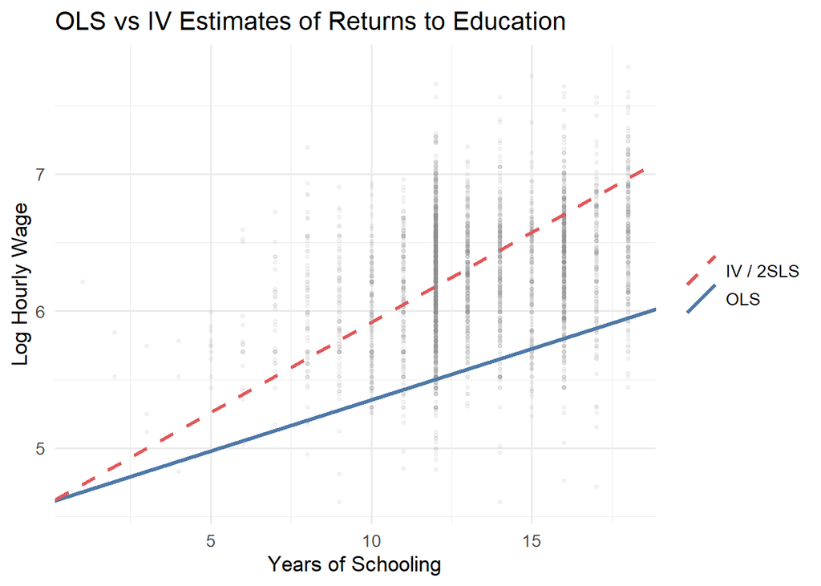

```r
library(ggplot2)
ggplot(card, aes(x = educ, y = lwage)) +
  geom_point(alpha = 0.08, colour = "#888888", size = 0.8) +
  geom_abline(aes(intercept = min(lwage),
                  slope = ols$coefficients["educ"],
                  colour = "OLS"),
              linewidth = 1.2) +
  geom_abline(aes(intercept = min(lwage),
                  slope = twosls$coefficients["educ_hat"],
                  colour = "IV / 2SLS"),
              linewidth = 1.2,
              linetype = "dashed") +
  scale_colour_manual(values = c("OLS" = "#4E79A7",
                                 "IV / 2SLS" = "#E15759")) +
  labs(title    = "OLS vs IV Estimates of Returns to Education",
       x        = "Years of Schooling",
       y        = "Log Hourly Wage",
       colour   = NULL) +
  theme_minimal(base_size = 13)
```